# Strava Analysis 2020

Dubravko Dolic

30 12 2020

# Running 2020 - all runs summary

The following visualizations are done with data from [Strava](https://www.strava.com/dashboard). Although Strava itself already allows a good deal of analyses I was curious what else could be done. So I checked out the API and here we are.

## Kudoers

Let’s have a look at the most exiting category: *Kudos*. These little somethings light up our days after a run. It can be a second reward for a run - apart from the run itself. So let’s have a closer look.

### Number of kudoes and kudoers

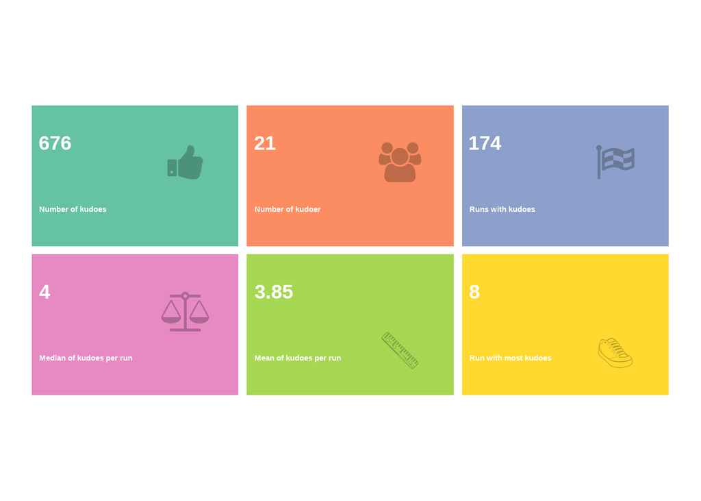

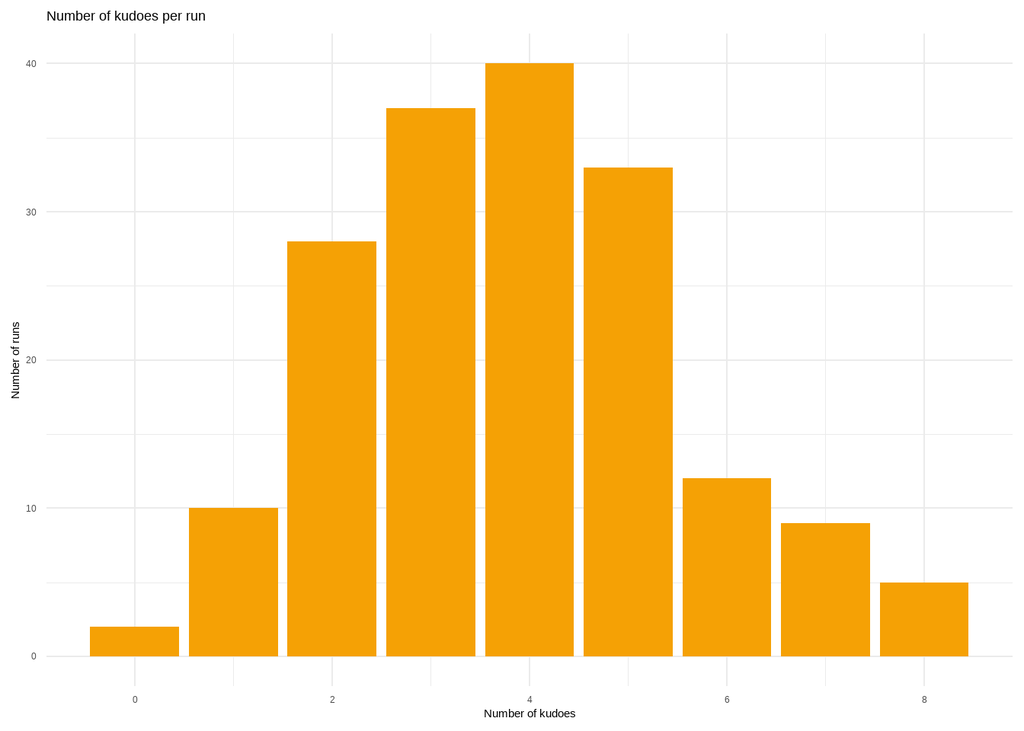

So, not a vast amount of kudoers but a very nice number of kudoes recieved already. Happy about that and thankful for this huge amount of motivation.

Now let’s see what I could do to receive more kudos next year. What is it that drives the number of kudoes? Is it the distance I do? Maybe the duration? Or do I have to be real fast?

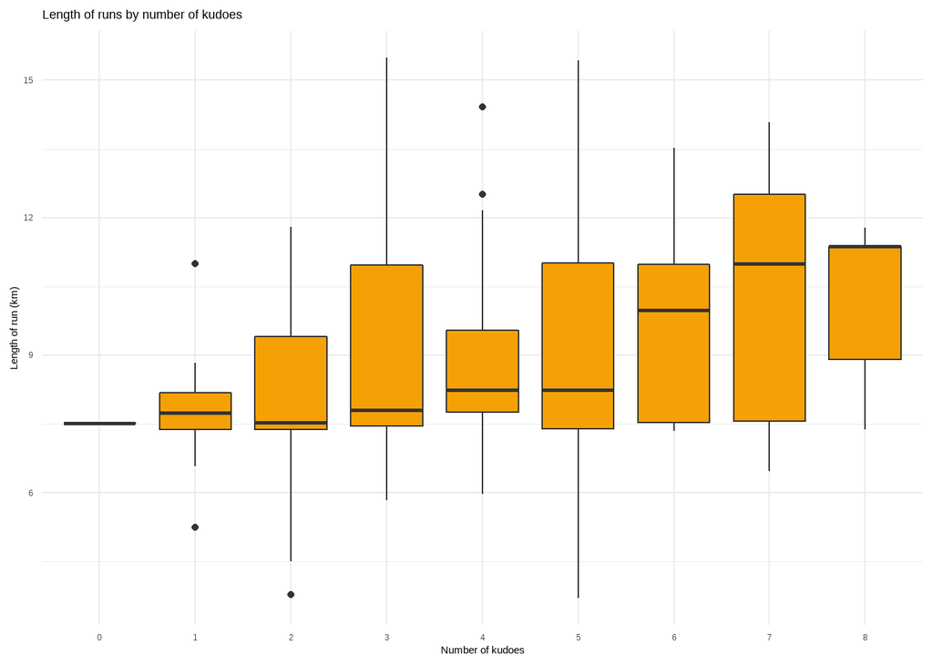

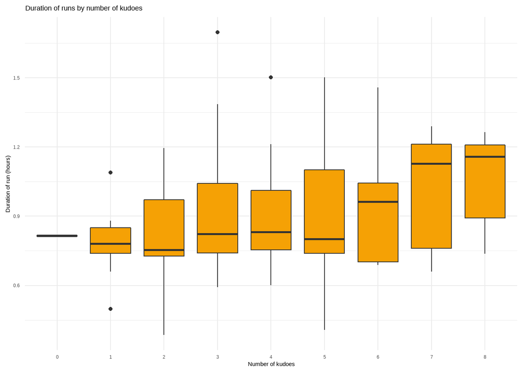

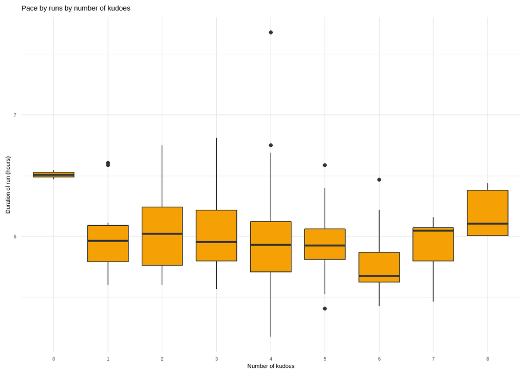

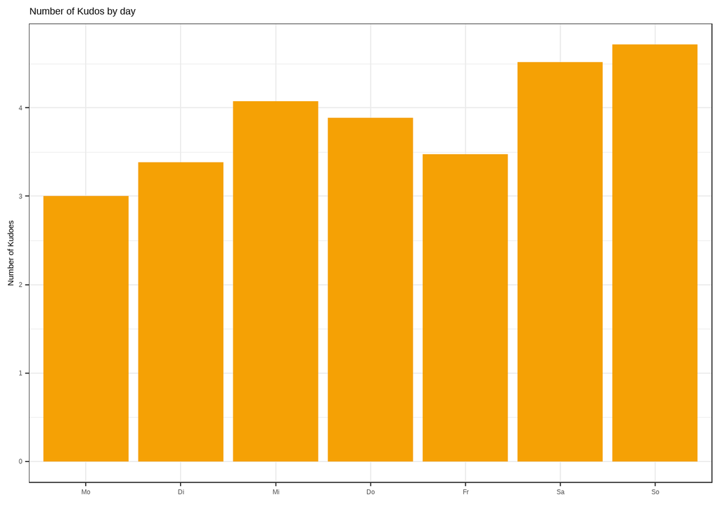

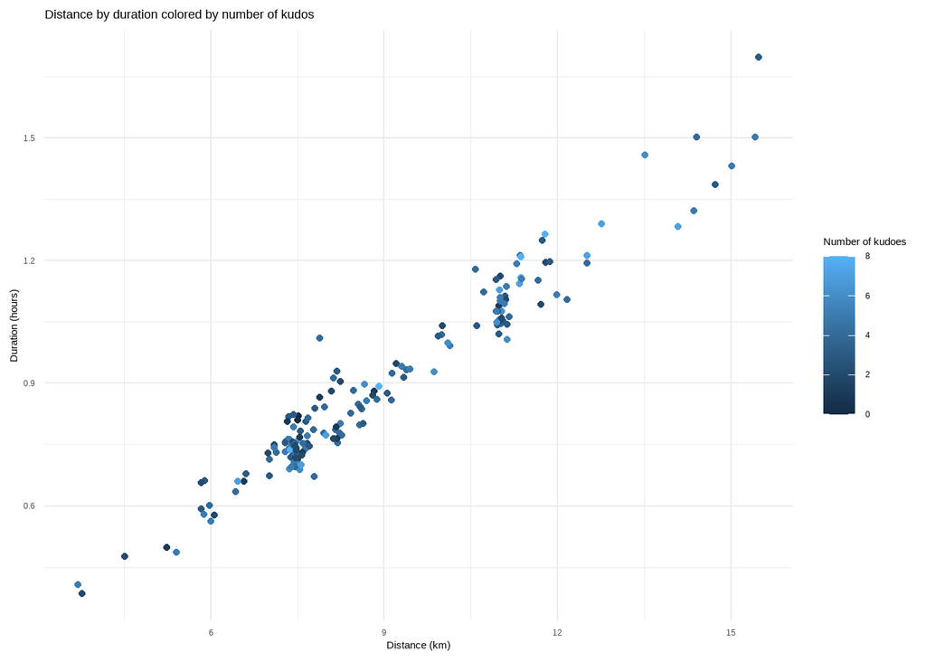

Now here is the most exiting chart: who is doing the best job as motivator? The answer is…

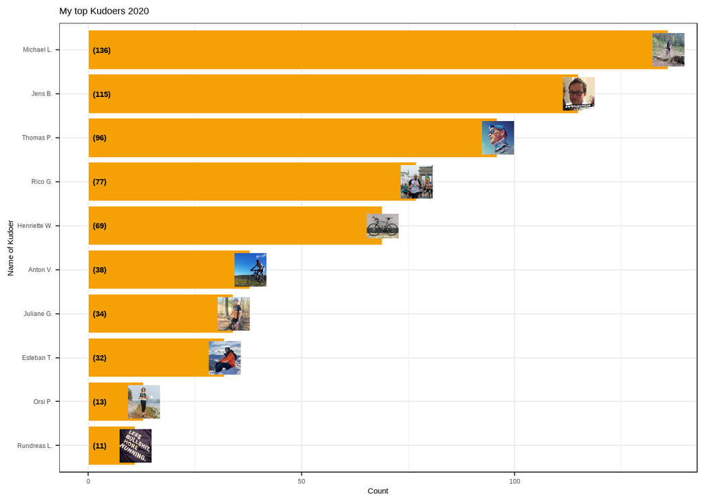

## My shoes

Clearly shoes are the most import gear for every runner. So I have a closer look on my gear. While Strava allows me to track the mileage of each shoe, I was interested on other parameters like speed, frequency of wear and duration.

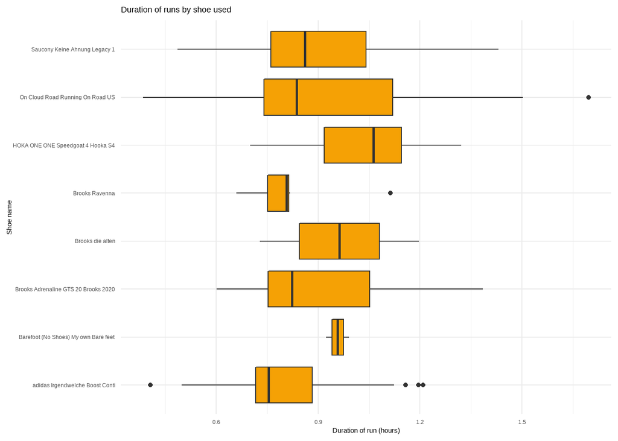

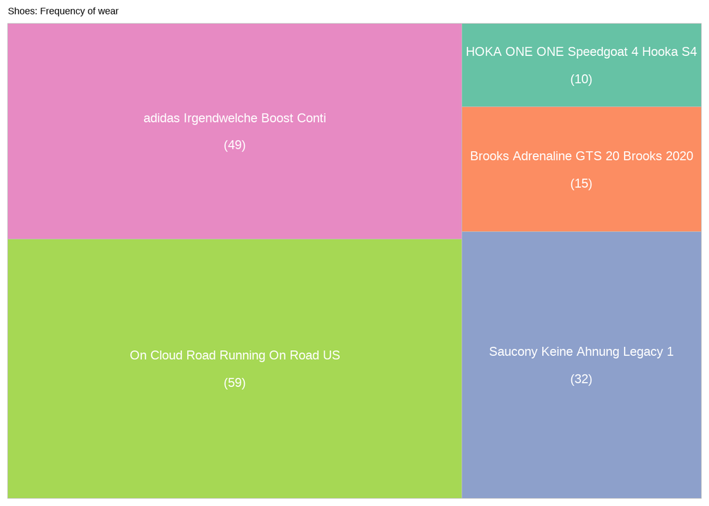

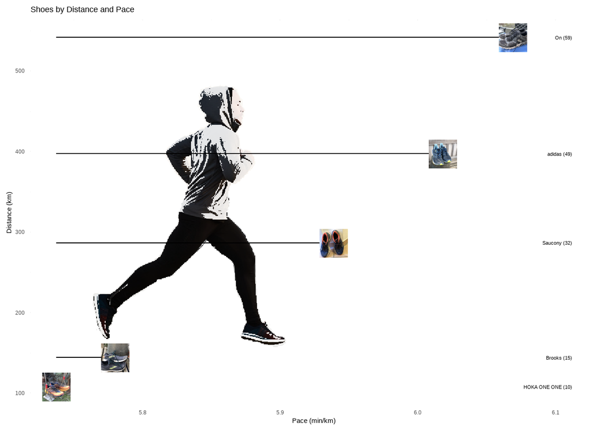

While my Hoka ONE ONE are giving me pace the ON shoes were my most frequently used one. Actually I was a little bit astonished because the usage was less than I expected.

## Suffer Score

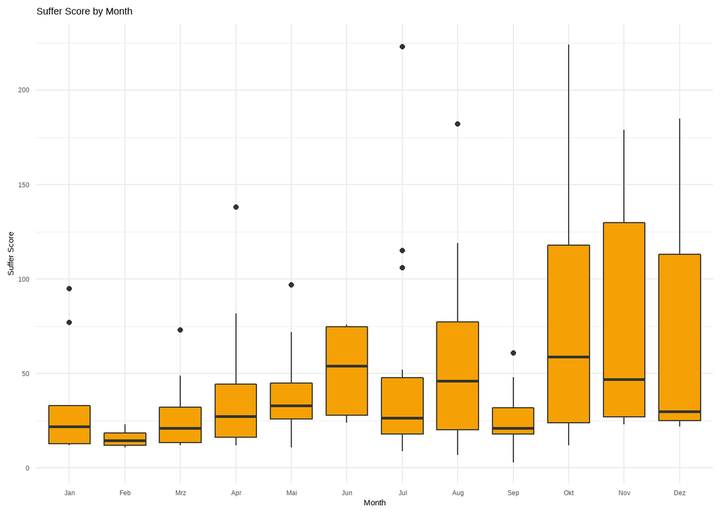

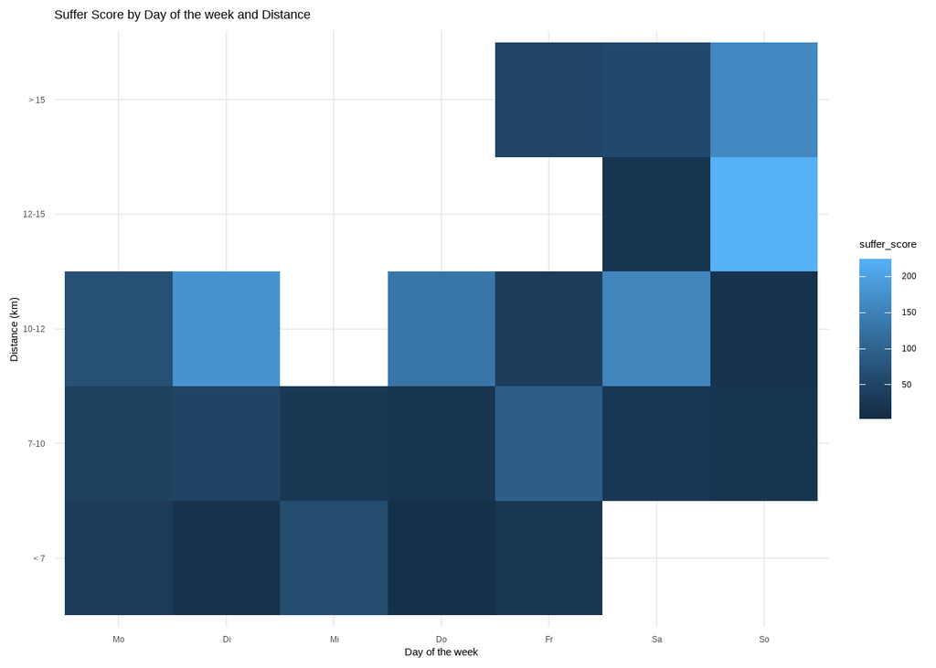

## Runs

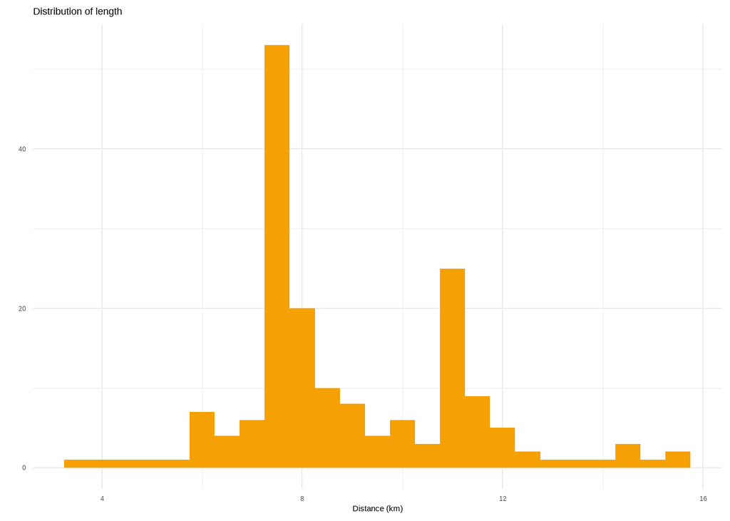

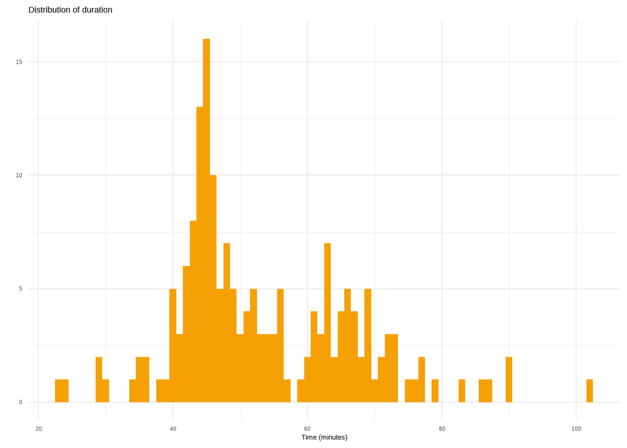

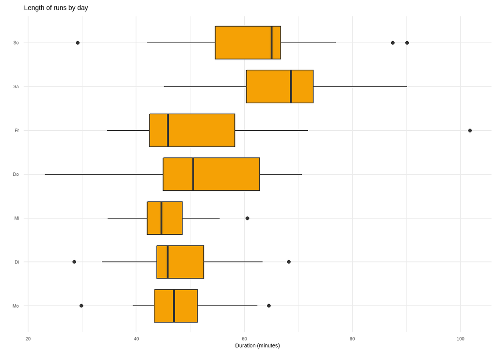

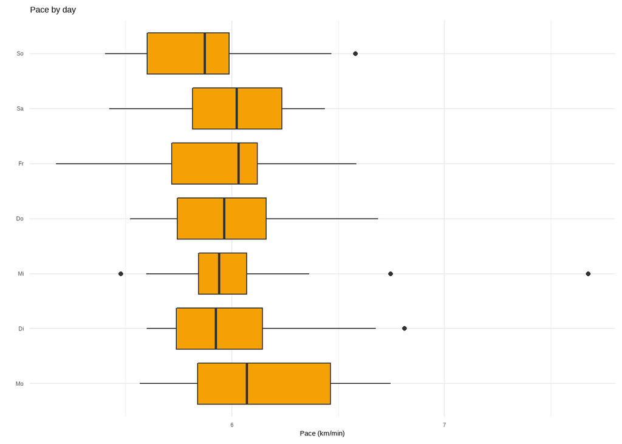

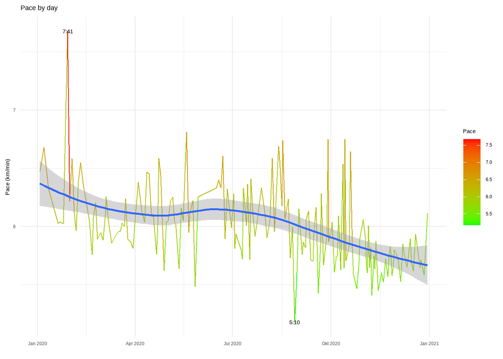

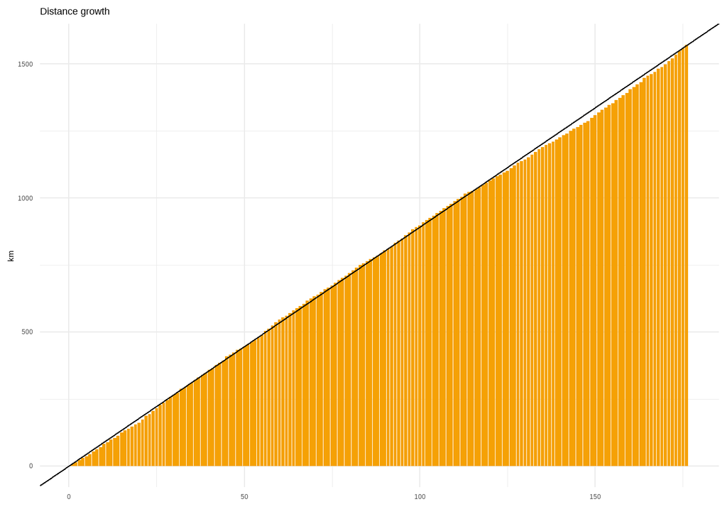

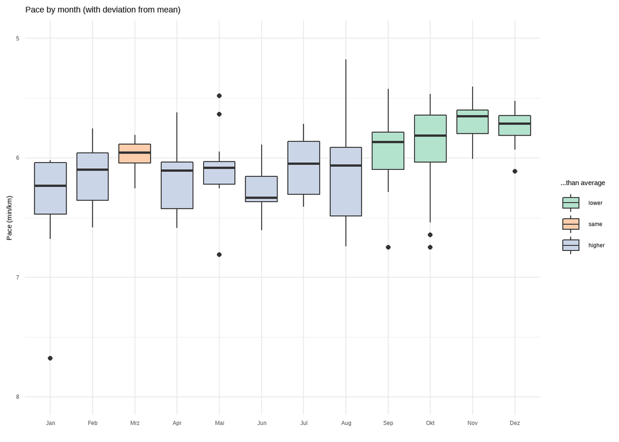

[output not shown]

[output cut: 70 more lines]

[output not shown]

[output not shown]

[output cut: 562 more lines]

[output not shown]

[output not shown]

[output cut: 16 more lines]

[output not shown]

[output not shown]

[output cut: 64 more lines]

[output not shown]

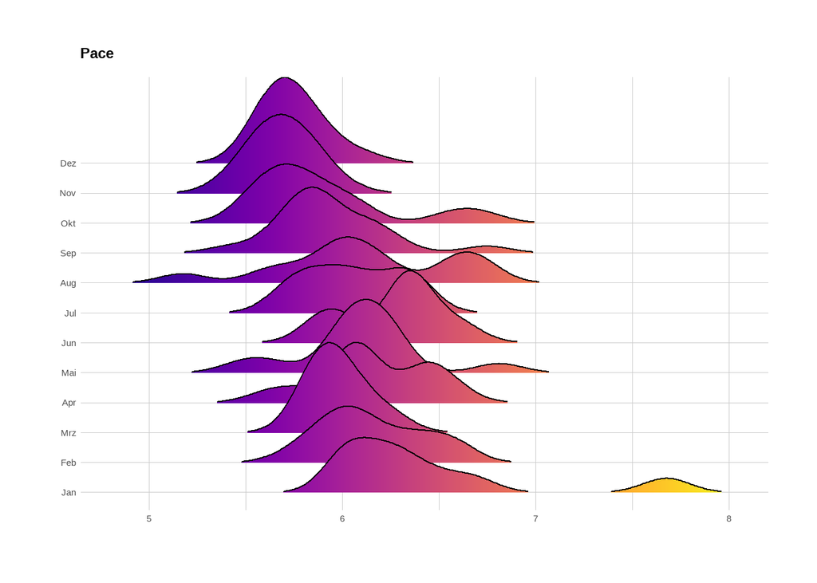

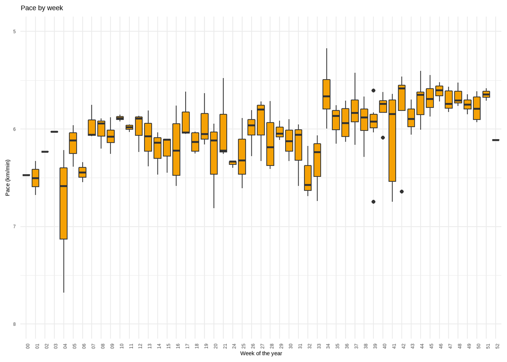

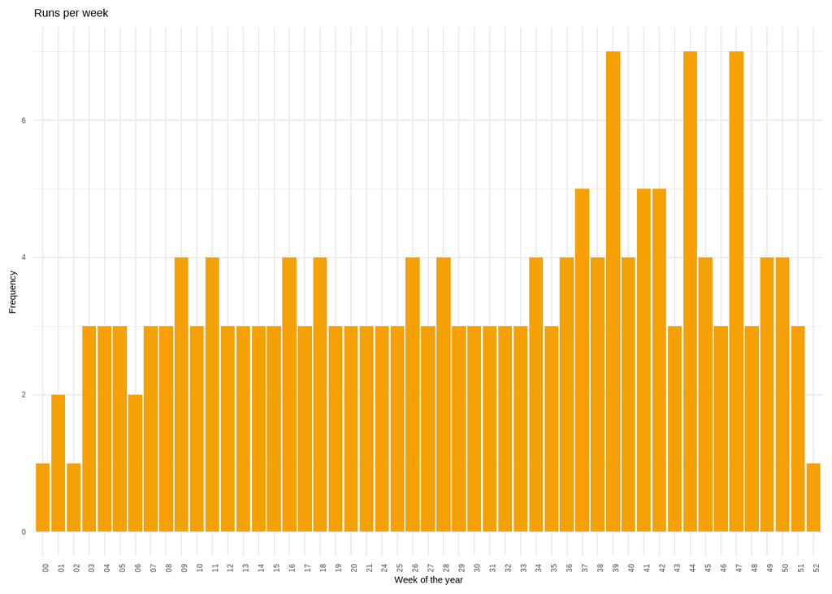

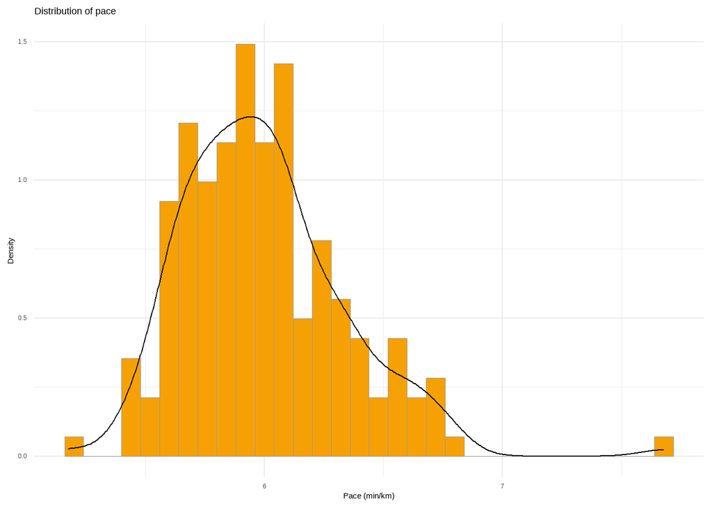

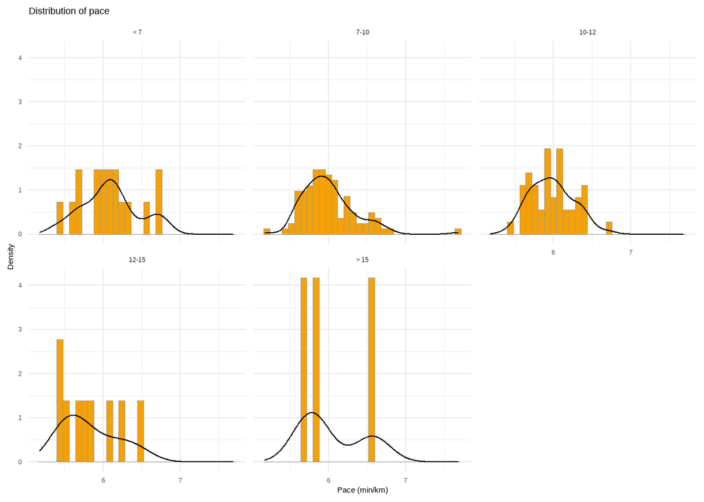

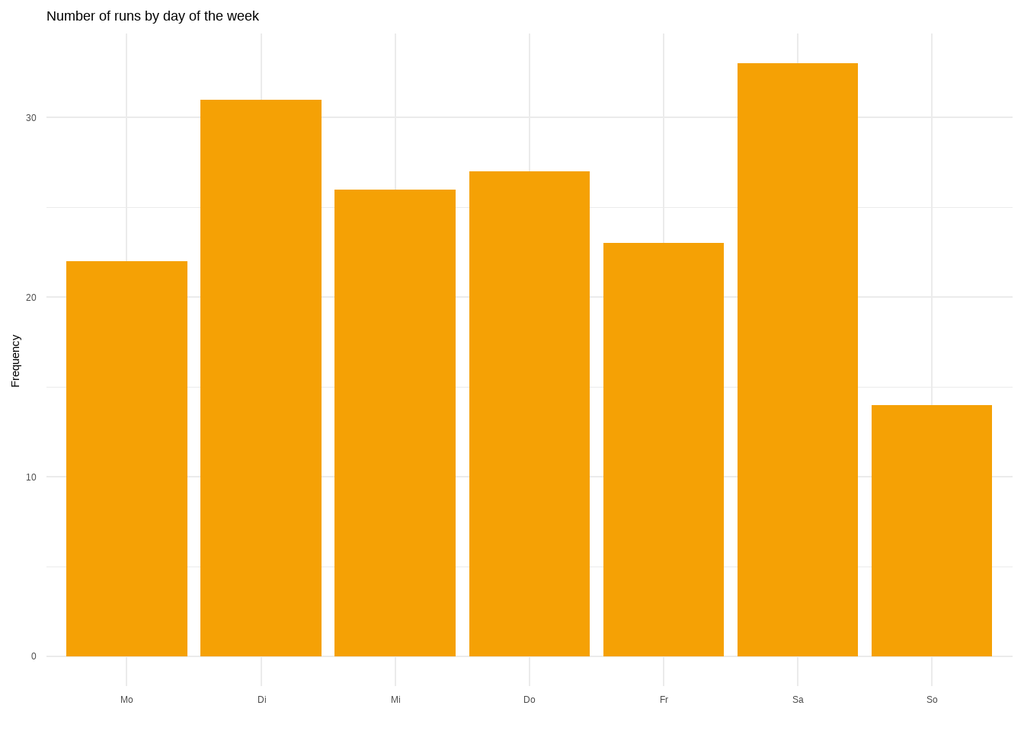

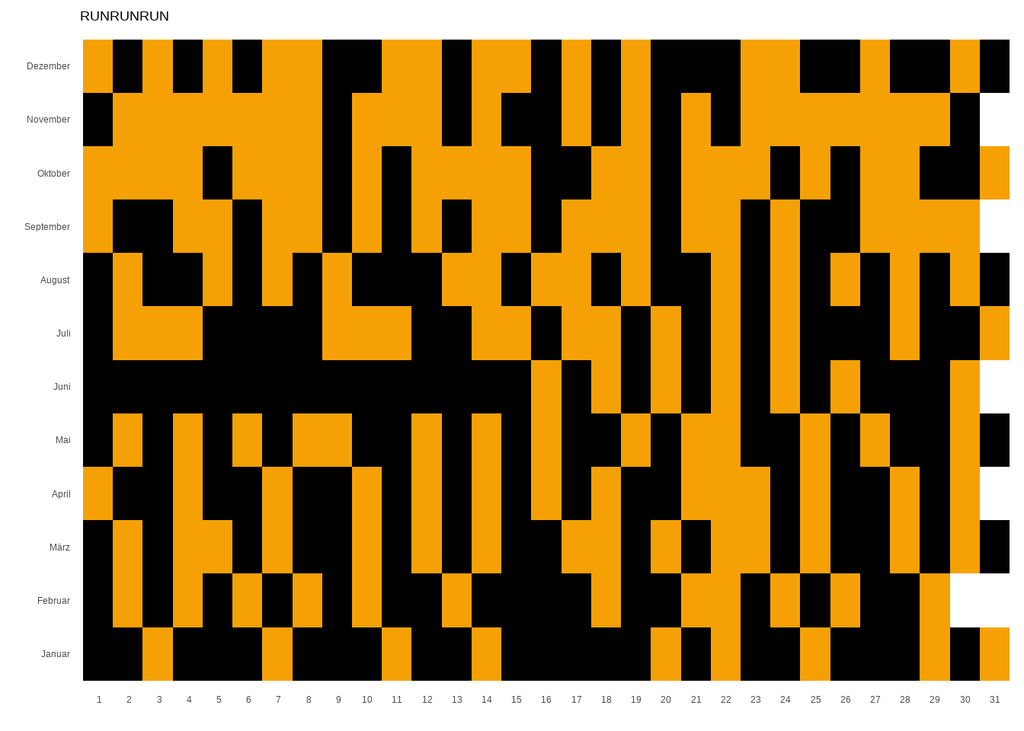

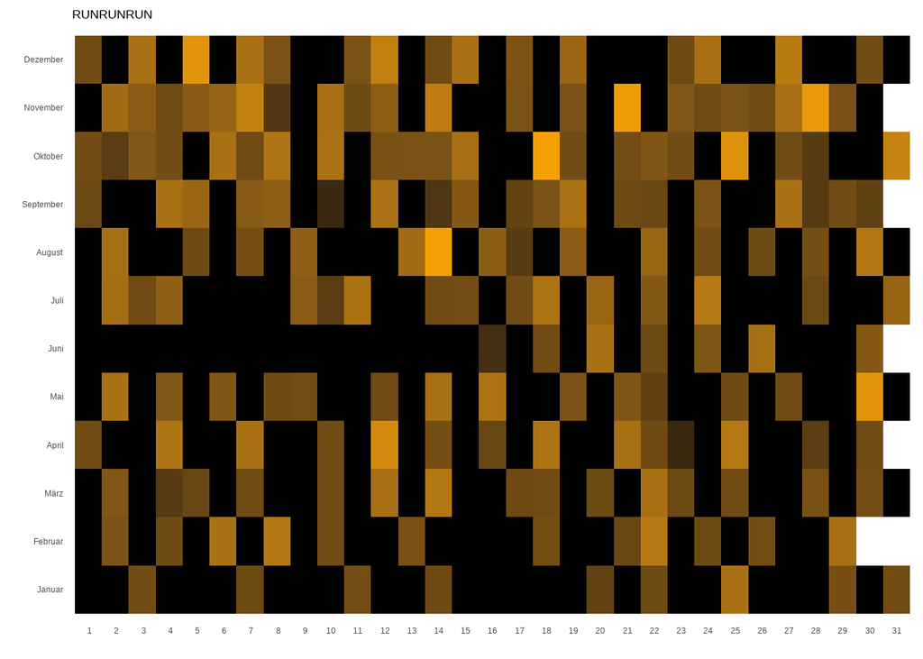